# Problem Set 04

Author

Published

2025-09-20

# Problems

### 1.

- Using the NC Births dataset (see last week’s HW for details), solve the following problems:
- Write a code block that uses count to get the counts of cases by mother’s smoking status and the baby’s term status (premature or full term). That is, we want the output to tell us four pieces of information
- how many non-smoking mothers had full term babies
- how many non-smoking mothers had premature babies
- how many smoking mothers had full term babies
- how many smoking mothers had premature babies.

```r
library(readr)
library(dplyr)
nc_births <- read_tsv("~/Bio724/nc-births.txt")
nc_births |>
  group_by(smoke, premature) |>
  count()
```

```
# A tibble: 4 × 3
# Groups:   smoke, premature [4]
  smoke     premature     n
  <chr>     <chr>     <int>
1 nonsmoker full term    87
2 nonsmoker premie       13
3 smoker    full term    42
4 smoker    premie        8
```

### 2

- Use group_by and summarize to calculate the median weights of babies for all four combinations of term classification and mother’s smoking status.

```r
nc_births |>
  group_by(smoke, premature) |>
  summarize(median_weight = median(weight))
```

```
# A tibble: 4 × 3
# Groups:   smoke [2]
  smoke     premature median_weight
  <chr>     <chr>             <dbl>
1 nonsmoker full term          7.5
2 nonsmoker premie             5.06
3 smoker    full term          7.31
4 smoker    premie             4.62
```

### 3

Use the penguins data from the palmerpenguins package in the following problems: * slice is a dplyr function that allows you to index rows by their integer locations. Show how to use the seq function and slice to get every fifth row in the penguins data set.

```r
penguin_data <- read.csv("~/Bio724/penguins.csv")

#penguin_data |>
  #slice(1:344, by = 5 )

penguin_data |>
  slice(seq(1, 344, by = 5)) #starting at the first row
```

```
     species    island bill_length_mm bill_depth_mm flipper_length_mm
1     Adelie Torgersen           39.1          18.7               181
2     Adelie Torgersen           39.3          20.6               190
3     Adelie Torgersen           37.8          17.1               186
4     Adelie Torgersen           36.6          17.8               185
5     Adelie    Biscoe           37.8          18.3               174
6     Adelie    Biscoe           35.3          18.9               187
7     Adelie     Dream           39.5          16.7               178
8     Adelie     Dream           39.2          21.1               196
9     Adelie     Dream           36.5          18.0               182
10    Adelie     Dream           39.6          18.8               190
11    Adelie    Biscoe           39.6          17.7               186
12    Adelie    Biscoe           41.4          18.6               191
13    Adelie    Biscoe           35.7          16.9               185
14    Adelie    Biscoe           41.6          18.0               192
```

[output cut: 125 more lines]

```r
penguin_data |>
  slice(seq(5, 344, by = 5)) #starting at the fifth row
```

```
     species    island bill_length_mm bill_depth_mm flipper_length_mm
1     Adelie Torgersen           36.7          19.3               193
2     Adelie Torgersen           42.0          20.2               190
3     Adelie Torgersen           34.6          21.1               198
4     Adelie Torgersen           46.0          21.5               194
5     Adelie    Biscoe           38.8          17.2               180
6     Adelie    Biscoe           40.5          18.9               180
7     Adelie     Dream           36.4          17.0               195
8     Adelie     Dream           39.8          19.1               184
9     Adelie     Dream           37.0          16.9               185
10    Adelie     Dream           42.3          21.2               191
11    Adelie    Biscoe           34.5          18.1               187
12    Adelie    Biscoe           37.6          19.1               194
13    Adelie    Biscoe           36.4          17.1               184
14    Adelie Torgersen           41.8          19.4               198
```

[output cut: 123 more lines]

### 4

Read the help documentation for the dplyr function slice_sample and then write a pipeline uses group_by and slice_sample that selects 5 random individuals from each of the species in the penguins data set.

```r
#slice_sample() randomly selects rows.

penguin_data |>
  group_by(species) |>
  slice_sample(n = 5)
```

```
# A tibble: 15 × 8
# Groups:   species [3]
   species   island   bill_length_mm bill_depth_mm flipper_length_mm body_mass_g
   <chr>     <chr>             <dbl>         <dbl>             <int>       <int>
 1 Adelie    Biscoe             39.6          20.7               191        3900
 2 Adelie    Torgers…           37.7          19.8               198        3500
 3 Adelie    Biscoe             42            19.5               200        4050
 4 Adelie    Dream              39.5          16.7               178        3250
 5 Adelie    Torgers…           37.8          17.3               180        3700
 6 Chinstrap Dream              47.5          16.8               199        3900
 7 Chinstrap Dream              50.8          19                 210        4100
 8 Chinstrap Dream              52.8          20                 205        4550
 9 Chinstrap Dream              49            19.5               210        3950
10 Chinstrap Dream              45.7          17                 195        3650
11 Gentoo    Biscoe             48.1          15.1               209        5500
12 Gentoo    Biscoe             48.4          14.4               203        4625
13 Gentoo    Biscoe             49.2          15.2               221        6300
14 Gentoo    Biscoe             46.6          14.2               210        4850
15 Gentoo    Biscoe             42            13.5               210        4150
# ℹ 2 more variables: sex <chr>, year <int>
```

### 5

Complete the following code to create an ordered factor with the categories “Low”, “Intermediate”, and “High”, indicating a coarse categorization of FLO11 expression as illustrated in the figure above:

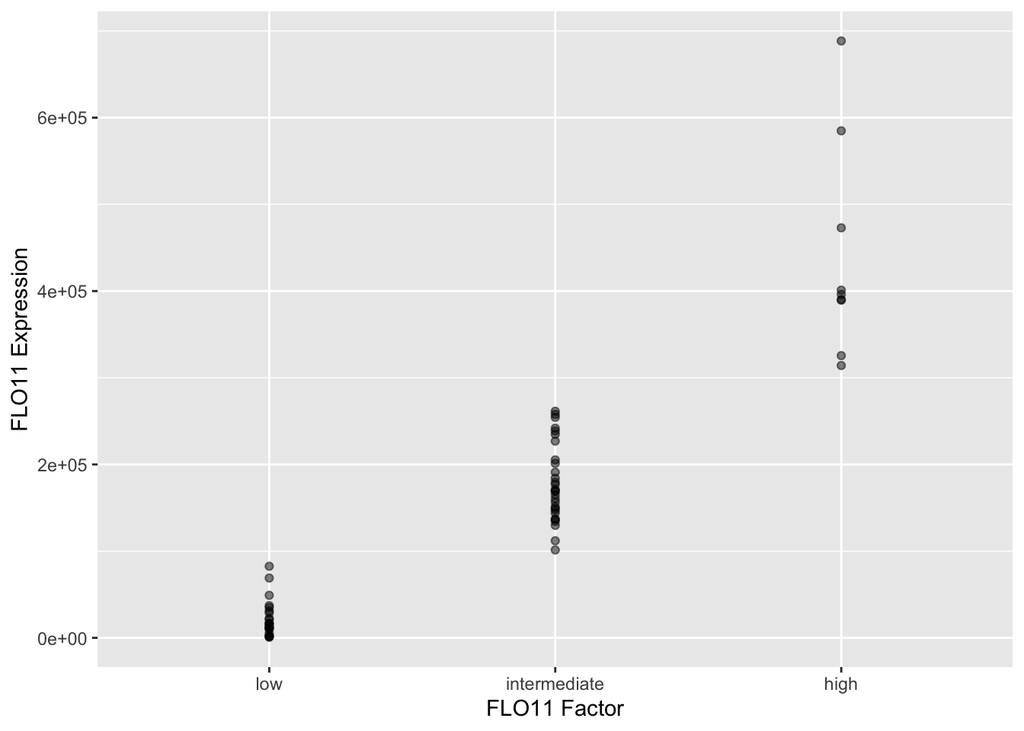

```r
library(ggplot2)

yeast <- read_csv("seg_strain_table.csv")
yeast |>
  mutate(Flo11.group = cut(Flo11.expr,
                           breaks = c(0, 100000, 300000, 800000),
                           labels = c("low", "intermediate", "high"),
                           ordered_results = TRUE)
         ) |>
  filter(!is.na(Flo11.group)) |>
  ggplot(aes(x = Flo11.group, y = Flo11.expr)) +
  geom_point(alpha=0.5) +
  labs(x = "FLO11 Factor", y = "FLO11 Expression")
```

## Data lunch

Learning about visual studio code and the feture for by passing the password step when logging into DCC was very helpful. I will implement these in my work and i think it will help eliminate some tidious steps.